# Nominator Racial Equity Analysis

Janette Avelar

5/23/2022

Tasks:  
* create survey year  
* randomized IDs for nominator orgs *before* uploading to GK + *after* bringing in race/ethnicity data

- bring in nom data with racial/ethnic info
- match to IDs
- remove cols with identifying info
- create separate dfs for year
- participation rates for each year disaggregated by race (after joining with nominated school dem)
- run models determining likelihood for each year by race (factor dems & year or independent models per year?)

# Visualizations

This first barchart depicts the racial distribution of targeted organization’s leadership team for all participating organizations from 2019-2021. The term *targeted* is indicating that we sent the organization a nomination survey.

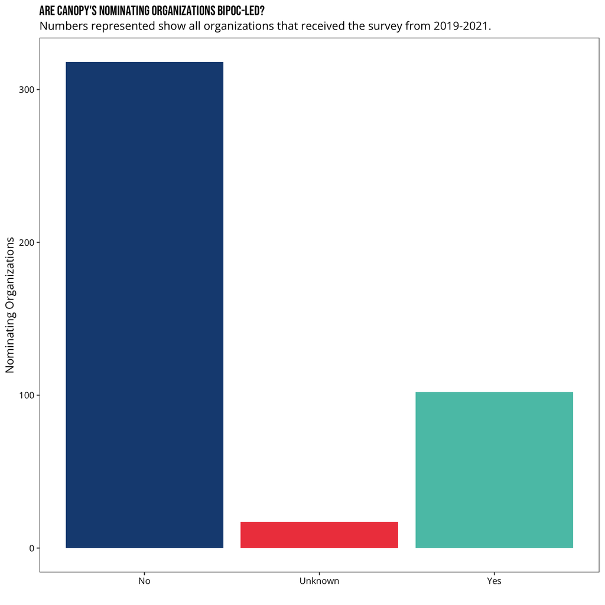

The second barchart depicts the racial distribution of nominating organizations’s leadership team, this time divided by year of participation.

Very interesting to note here that although the number of nominating organizations participating in the survey has grown, the demographics have remained steady across years. Our percentage of organizations not led by BIPOC leaders is at a steady 73% each year, with a 1% increase in BIPOC-led organizations per year and a 1% decrease in the organizations with unknown leadership demographics.

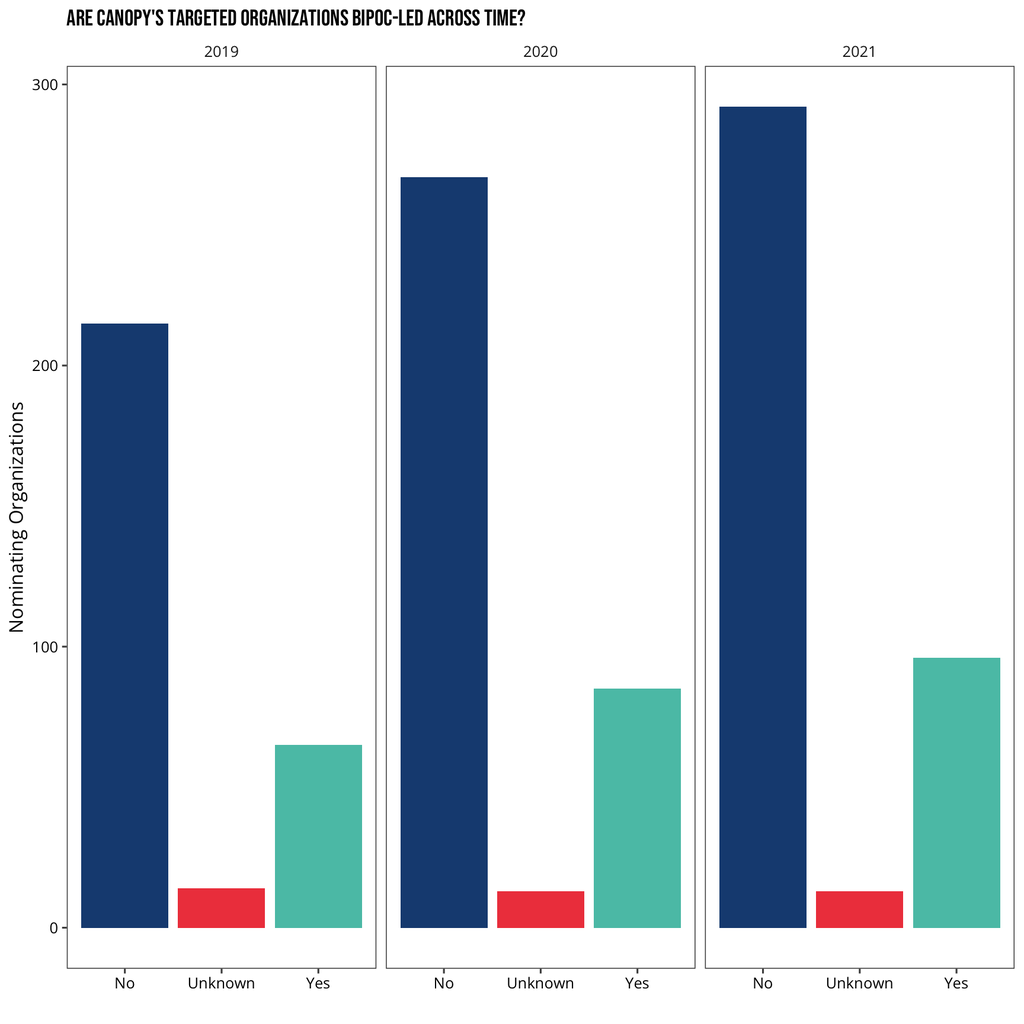

Below I’ll include the same breakdown for the individual nominators, but it’s important to keep in mind that this data may not be necessarily relevant for a variety of factors. For example, and perhaps most importantly, we don’t know how decisions about individual nominators were made within these organizations. Is someone asked to fill out on behalf of the organization? Are the nominations reflective of choices made by the nominator? Has a group convened to select schools to nominate? It may be too “noisy” to make meaning of, but we could consider if this is something to dig into for future surveys.

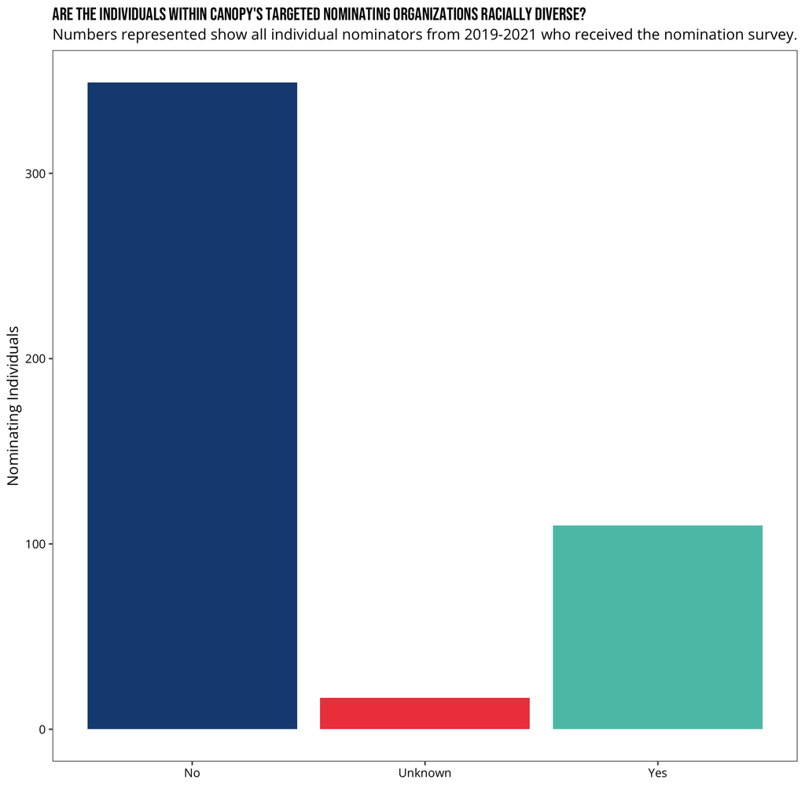

Racial diversity for individual nominators across the years:

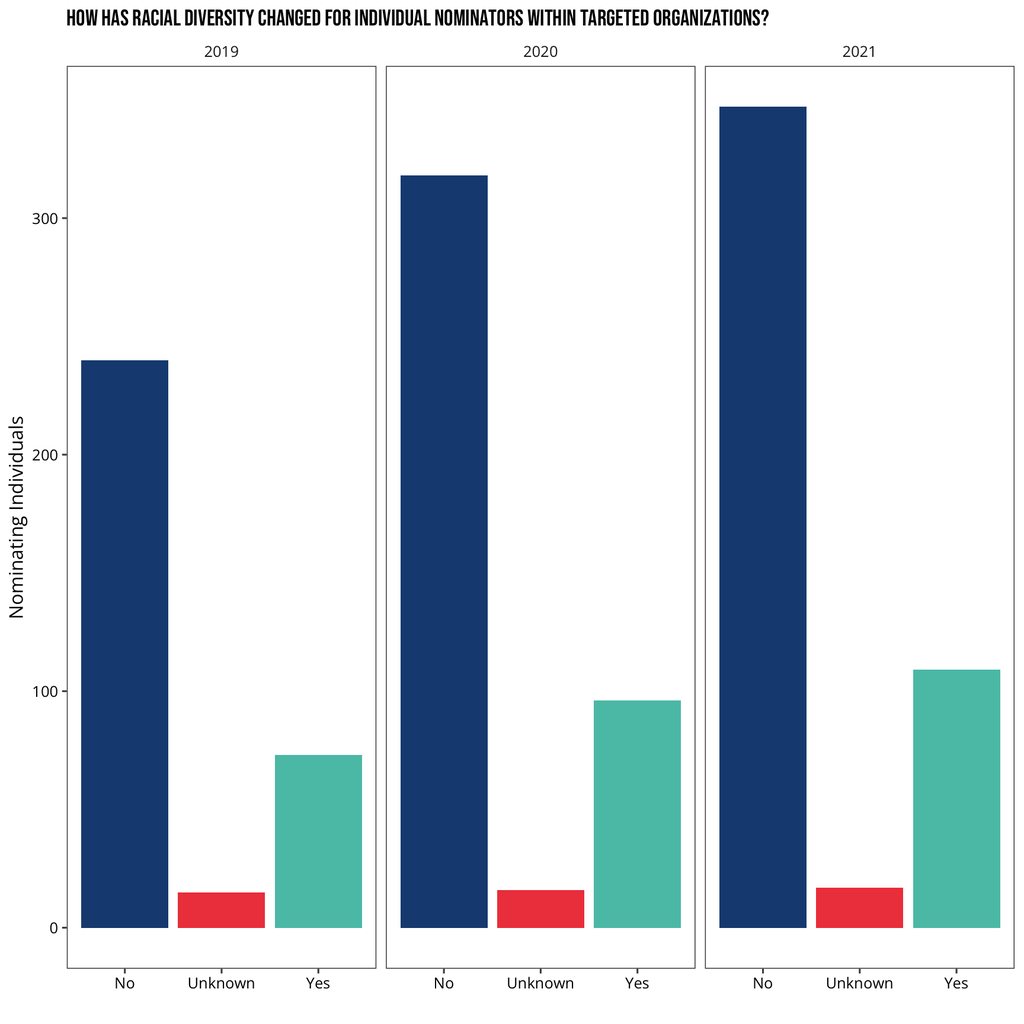

```
## [1] 17
```

Participation rates

For organizations split up by whether or not they are BIPOC-led:

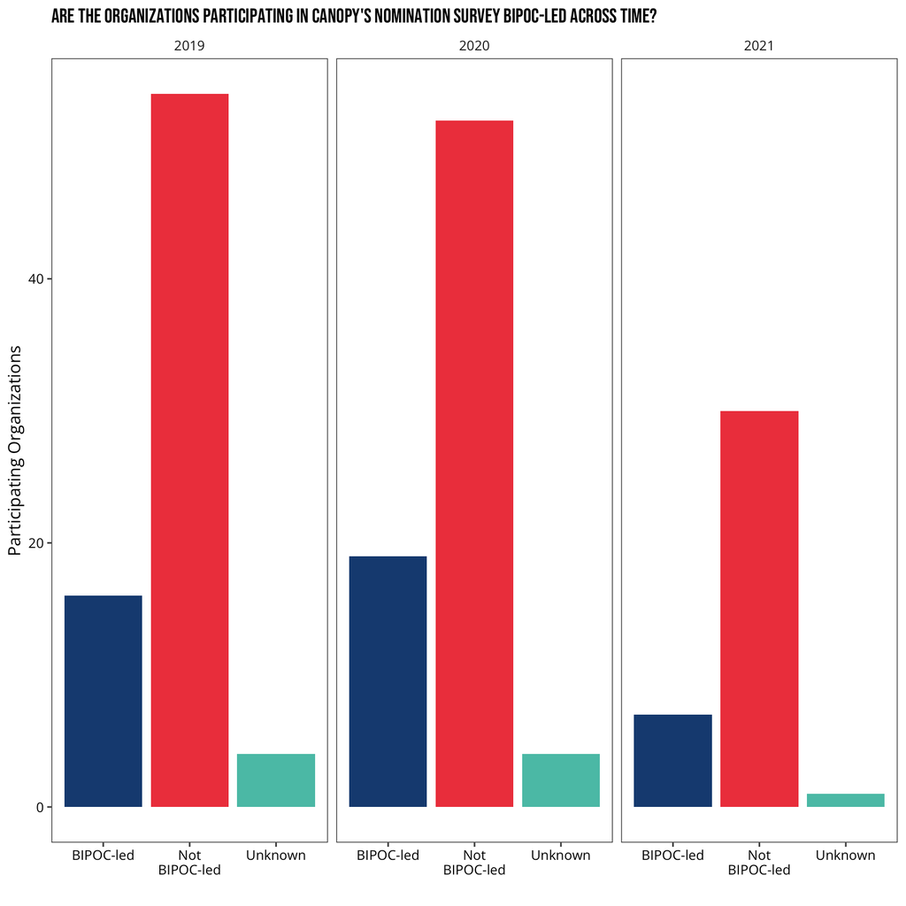

```
## [1] 9
```

For individual nominators’ racial identity:

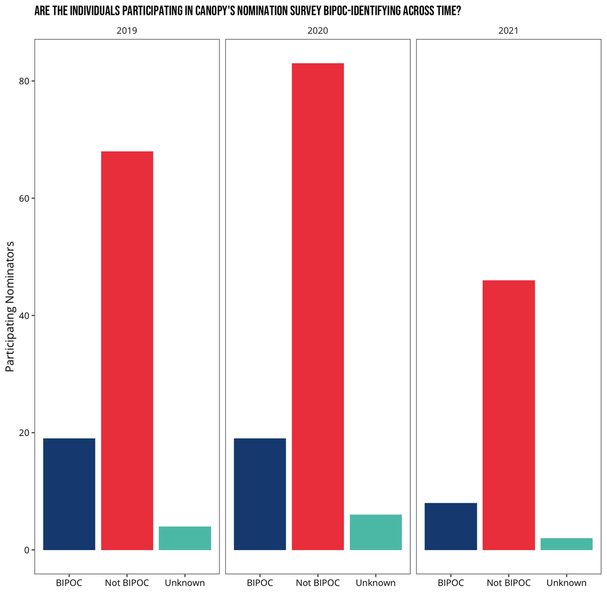

```
## [1] 255
```

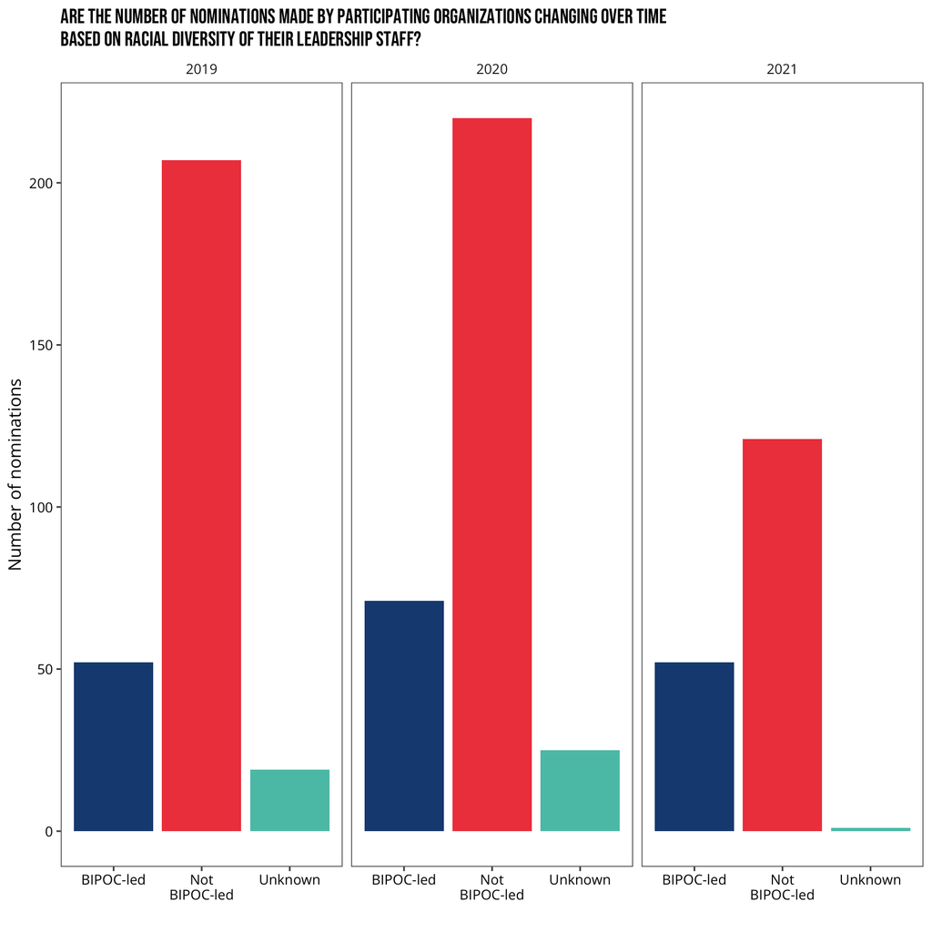

One clear thing we can pull out all of these graphs is that White-led organizations and White leaders are by far participating at much higher rates. On the other hand, this isn’t entirely surprising and matches fairly evenly with the rates of organizations we’re targeting. This makes me think that one potential first avenue to talk about lies in intentionally focusing on the racial demographics of the organizations who receive the nomination survey in the first place, and to make a plan at a future equity meeting after the upcoming year’s survey to determine if, and in which direction, the rates of participation change in relation to recruitment efforts.

Another thing to notice (once you add percentage information to the plot representing the number of nominations made) is that the proportion of nominations made by BIPOC-led nominating organizations has increased somewhat since 2019, from 19% to 30%. This may be promising and supportive of suggestion above, though should be looked at alongside the racial demographic disaggregated data for school leaders and leadership groups for participating schools.

Join 2021 nominator data with school survey data to compare nominations.

[output not shown]

What does school leadership look like in nominated schools?

```
## [1] 0
```

What does teaching staff look like in nominated schools?

What does the school leader look like in nominated schools?

Create plots, paste together at the end Some kind of correlation or odds ratio plot.